# Time Series Clustering COVID-19 Cases

Conor Tompkins

2020-07-20

This post will be about clustering COVID-19 case data. The goal is to group states into clusters based on the state’s cumulative sum of COVID-19 cases.

Load the packages I will use in the analysis and set up the environment:

```r
library(tidyverse)
library(tsibble)
library(dtwclust)
library(tidymodels)
library(hrbrthemes)
library(tidycensus)
library(sf)

options(scipen = 999, digits = 4)

theme_set(theme_ipsum())

set.seed(1234)
```

I will adjust the cases to per 100,000, which requires information from the U.S. Census. This code pulls state-level population data from the Census API via `tidycensus`:

```r
census_data <- get_acs(geography = "state", variables = "B01003_001", geometry = FALSE) %>%
  select(state = NAME, population = estimate)
```

This pulls the COVID-19 data from the NYTimes GitHub page:

```r
covid <- read_csv("https://raw.githubusercontent.com/nytimes/covid-19-data/master/us-states.csv") %>%
  arrange(state, date) %>%
  semi_join(census_data) %>%
  filter(date <= "2020-07-18")
```

I use the `tsibble` package to check if there are implicit gaps in the data. For example, if there was data for 2020-06-01 and 2020-06-03, there is an implicit gap because there is not data for 2020-06-02.

```r
covid %>%
  as_tsibble(index = date, key = state) %>%
  count_gaps()
```

```
## # A tibble: 0 x 4
## # … with 4 variables: state <chr>, .from <date>, .to <date>, .n <int>
```

Thankfully, there are not any such gaps. If there were, I would have to impute values for the missing days.

Since states experienced onset of COVID-19 at different times, I find the day each state hit 10 cases, and calculate `days_since_10th_case`, which I will use instead of `date`.

```r
covid_10th_case <- covid %>%
  filter(cases >= 10) %>%
  group_by(state) %>%
  slice(1) %>%
  ungroup() %>%
  select(state, date_of_10th_case = date)

covid <- covid %>%
  left_join(covid_10th_case, by = c("state" = "state")) %>%
  group_by(state) %>%
  mutate(days_since_10th_case = date - date_of_10th_case) %>%
  ungroup() %>%
  filter(days_since_10th_case >= 0)

covid <- covid %>%
  select(state, days_since_10th_case, cases)
```

Next I calculate `cases_per_capita`:

```r
covid <- covid %>%
  left_join(census_data) %>%
  mutate(cases_per_capita = (cases / population) * 100000) %>%
  select(-population)
```

Next I scale the cases so that the mean is 0 and the standard deviation is 1. Each state has its own mean and standard deviation.

```r
covid <- covid %>%
  group_by(state) %>%
  mutate(cases_per_capita_scaled = scale(cases_per_capita, center = TRUE, scale = TRUE)) %>%
  ungroup()
```

The result of this is that the clustering algorithm will focus on the *shape* of the line for each state instead of absolute values. This graph shows the difference:

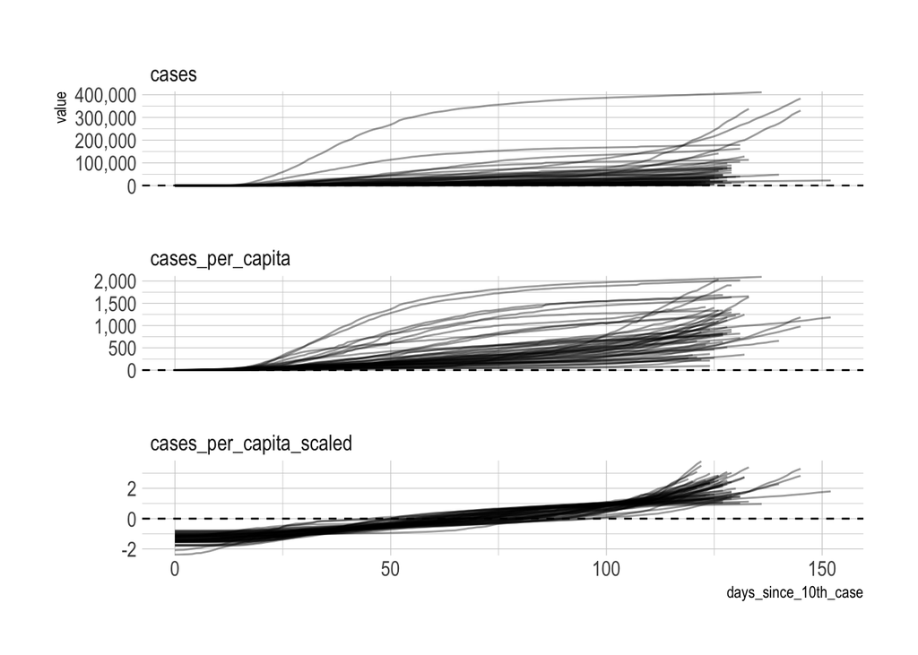

```r
covid %>%
  pivot_longer(cols = contains("cases"), names_to = "metric", values_to = "value") %>%
  ggplot(aes(days_since_10th_case, value, group = state)) +
  geom_line(alpha = .4) +
  geom_hline(yintercept = 0, linetype = 2) +
  facet_wrap(~metric, ncol = 1, scales = "free_y") +
  scale_y_comma()
```

`tsclust` requires that the input data be a series of lists, not a dataframe. `unstack` takes a `key` and `value` as arguments and turns the dataframe into a list of lists.

```r
covid_list <- covid %>%
  select(state, cases_per_capita_scaled) %>%
  unstack(cases_per_capita_scaled ~ state)
```

This loops through the clustering function 20 times and saves each output to a list. The first object groups the data into 2 clusters, the second object has 3 clusters, and it continues in that pattern.

```r
cluster_dtw_h <- list()

kclust <- 20

for (i in 2:kclust){
  cluster_dtw_h[[i]] <- tsclust(covid_list,
                                type = "h",
                                k = i,
                                distance = "dtw",
                                control = hierarchical_control(method = "complete"),
                                seed = 390,
                                preproc = NULL,
                                args = tsclust_args(dist = list(window.size = 21L)))

  print(i)
}
```

The object that `tsclust` outputs has a complex structure that makes it difficult to work with at scale. The data I need to pull out is stored in various slots:

```r
slotNames(cluster_dtw_h[[2]])
```

[output not shown]

```r
str(cluster_dtw_h[[2]])
```

The next step is to write functions that pulls out the data and tidies it up.

This function pulls which cluster each state was assigned to, for each `kclust`.

```r
get_cluster_assignments <- function(object, cluster_number){

  df <- slot(object[[cluster_number]], "cluster")

  return(df)
}
```

```r
cluster_assignments <- 2:kclust %>%
  set_names() %>%
  map_df(~get_cluster_assignments(cluster_dtw_h, cluster_number = .x), .id = "kclust") %>%
  pivot_longer(cols = -kclust, names_to = "state", values_to = "cluster_assignment") %>%
  mutate(kclust = as.numeric(kclust)) %>%
  arrange(state, kclust)
```

```r
glimpse(cluster_assignments)
```

```
## Rows: 988
## Columns: 3
## $ kclust             <dbl> 2, 2, 2, 2, 2, 2, 2, 2, 2, 2, 2, 2, 2, 2, 2, 2, 2,…
## $ state              <chr> "Alabama", "Alaska", "Arizona", "Arkansas", "Calif…
## $ cluster_assignment <dbl> 1, 1, 1, 1, 1, 1, 1, 1, 1, 1, 1, 1, 1, 1, 1, 1, 1,…
```

These graphs shows which states are more likely to be assigned to a different cluster, depending on the number of clusters.

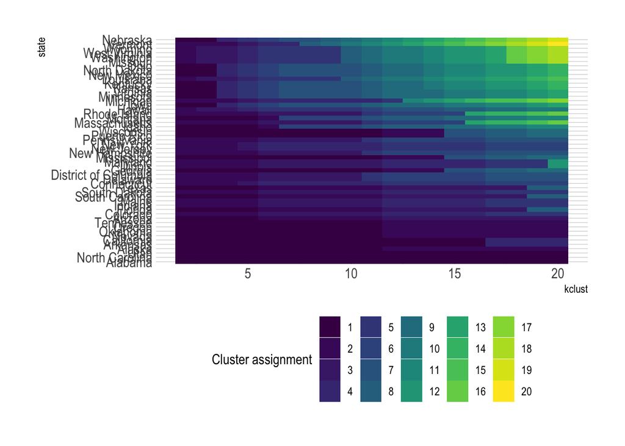

```r
state_variance <- cluster_assignments %>%
  distinct(state, cluster_assignment) %>%
  count(state, sort = TRUE)

cluster_assignments %>%
  left_join(state_variance) %>%
  mutate(state = fct_reorder(state, n)) %>%
  ggplot(aes(kclust, state, fill = as.factor(cluster_assignment))) +
  geom_tile() +
  scale_fill_viridis_d() +
  labs(fill = "Cluster assignment") +
  theme(legend.position = "bottom", legend.direction = "horizontal")
```

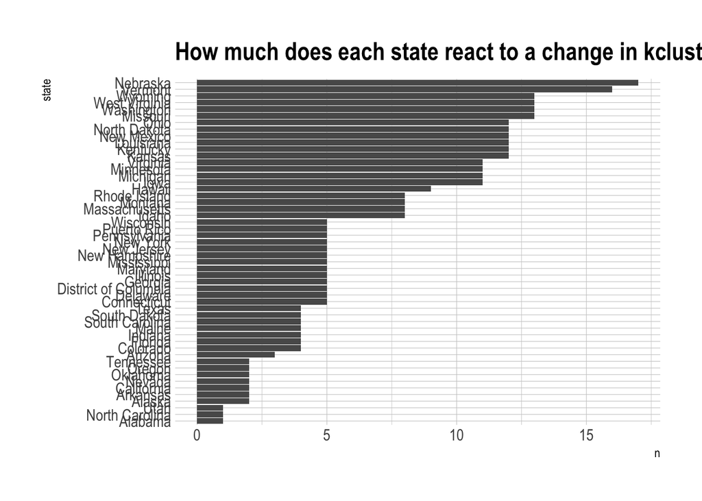

```r
cluster_assignments %>%
  distinct(state, cluster_assignment) %>%
  count(state) %>%
  mutate(state = fct_reorder(state, n)) %>%
  ggplot(aes(n, state)) +
  geom_col() +
  labs(title = "How much does each state react to a change in kclust?")
```

The number of singelton clusters (clusters with only one state) is an important metric for determining the optimal number of clusters. If a state is truly unique, a singleton cluster may be appropriate. Having 50 singleton clusters, however, would obviously be overfit.

This shows that the number of singleton clusters increases as `kclust` increases.

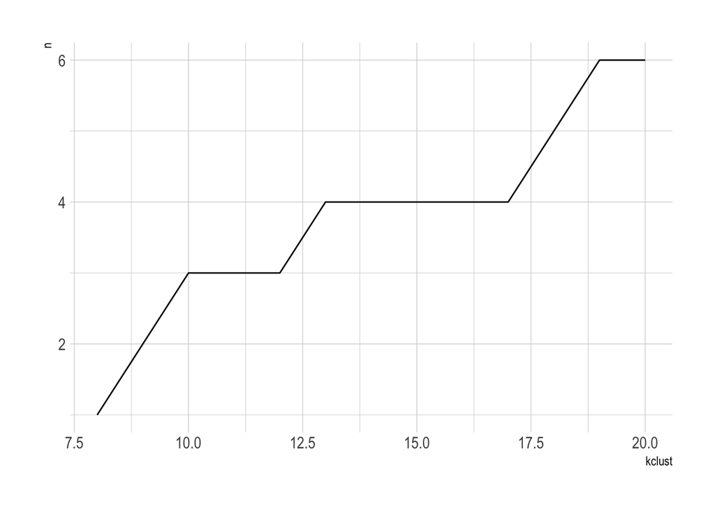

```r
cluster_singletons <- cluster_assignments %>%
  count(kclust, cluster_assignment) %>%
  group_by(kclust) %>%
  mutate(min_cluster_population = min(n)) %>%
  ungroup() %>%
  filter(n == min_cluster_population) %>%
  ungroup() %>%
  select(kclust, min_cluster_population, n) %>%
  group_by(kclust, min_cluster_population) %>%
  summarize(n = sum(n)) %>%
  ungroup()

cluster_singletons %>%
  filter(min_cluster_population == 1) %>%
  ggplot(aes(kclust, n)) +
  geom_line()
```

There is not a singleton cluster until `kclust` is 8.

```r
cluster_singletons %>%
  mutate(first_singleton = cumsum(min_cluster_population == 1) == 1) %>%
  filter(first_singleton == TRUE)
```

```
## # A tibble: 1 x 4
##   kclust min_cluster_population     n first_singleton
##    <dbl>                  <int> <int> <lgl>
## 1      8                      1     1 TRUE
```

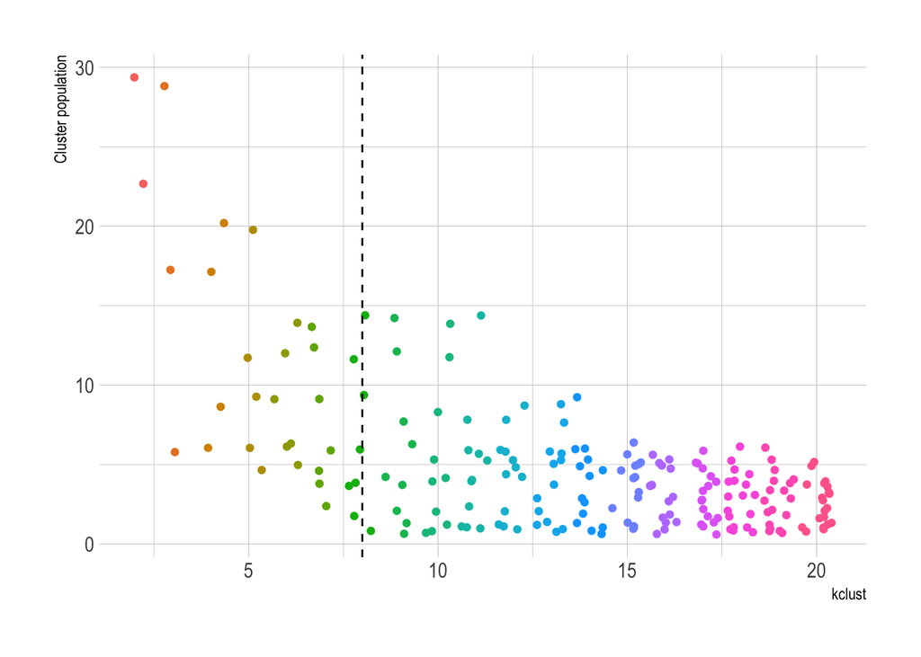

```r
cluster_assignments %>%
  count(kclust, cluster_assignment) %>%
  ggplot(aes(kclust, n, color = as.factor(kclust))) +
  geom_jitter(show.legend = FALSE) +
  geom_vline(xintercept = 8, linetype = 2) +
  labs(y = "Cluster population")
```

This function pulls the average distance of each cluster, for each value of `kclust`. Clusters with lower average distance are more similar, and those with higher average distance are less similar.

```r
get_cluster_metrics <- function(object, cluster_number){

  df <- slot(object[[cluster_number]], "clusinfo")

  return(df)
}
```

This shows that 12 clusters may be the optimal number for `kclust`. Values greater than that begin to see diminishing returns.

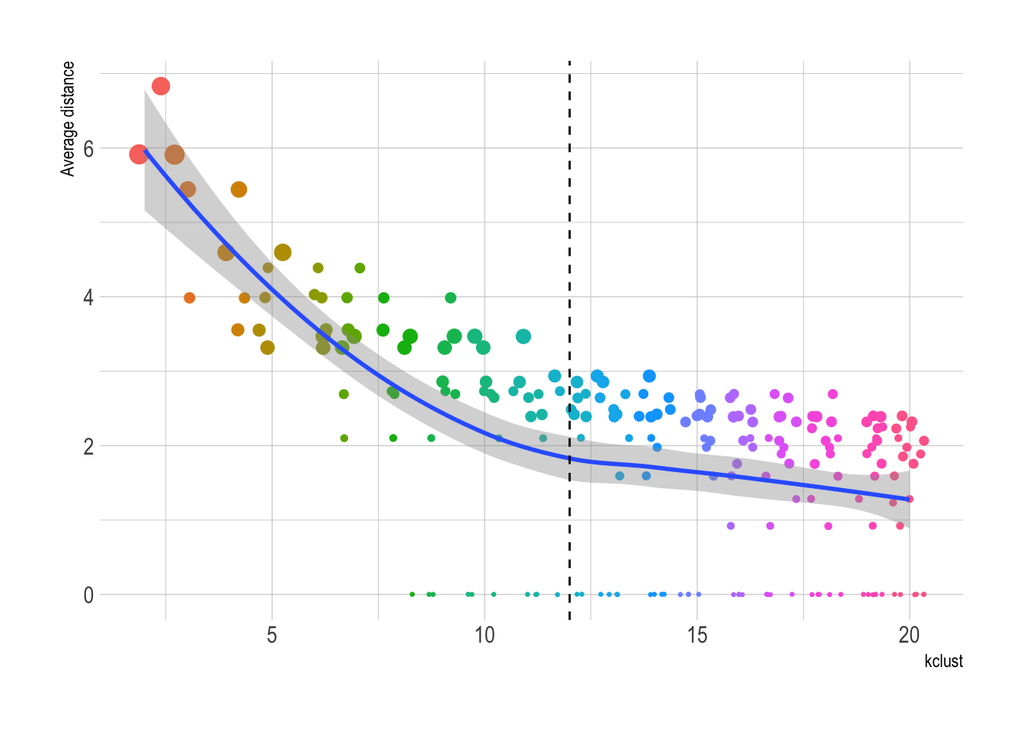

```r
cluster_metrics %>%
  ggplot(aes(kclust, av_dist)) +
  geom_jitter(aes(color = as.factor(kclust), size = size), show.legend = FALSE) +
  geom_smooth(group = 1) +
  geom_vline(xintercept = 12, linetype = 2) +
  scale_size_continuous(range = c(.5, 4)) +
  labs(y = "Average distance")
```

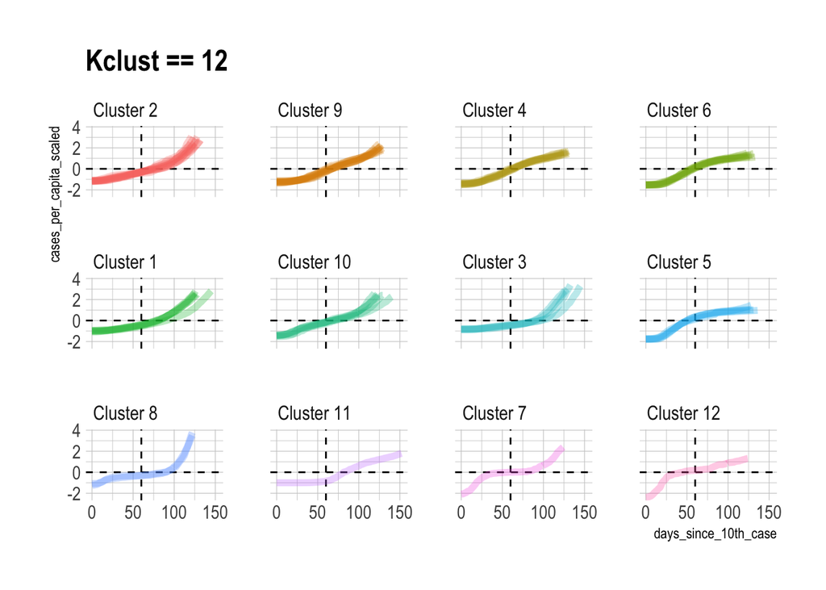

```r
best_kclust <- 12

covid %>%
  left_join(filter(cluster_assignments, kclust == best_kclust)) %>%
  add_count(cluster_assignment) %>%
  mutate(cluster_assignment = str_c("Cluster", cluster_assignment, sep = " "),
         cluster_assignment = fct_reorder(as.character(cluster_assignment), n),
         cluster_assignment = fct_rev(cluster_assignment)) %>%
  ggplot(aes(days_since_10th_case, cases_per_capita_scaled,
             color = cluster_assignment, group = state)) +
    geom_hline(yintercept = 0, linetype = 2) +
  geom_vline(xintercept = 60, linetype = 2) +
  geom_line(size = 2, alpha = .3) +
  facet_wrap(~cluster_assignment, ncol = 4) +
  guides(color = FALSE) +
  labs(title = "Kclust == 12")
```

## Mapping

The data is aggregated at the state level, which can easily be graphed with `ggplot2` and `tidycensus`.

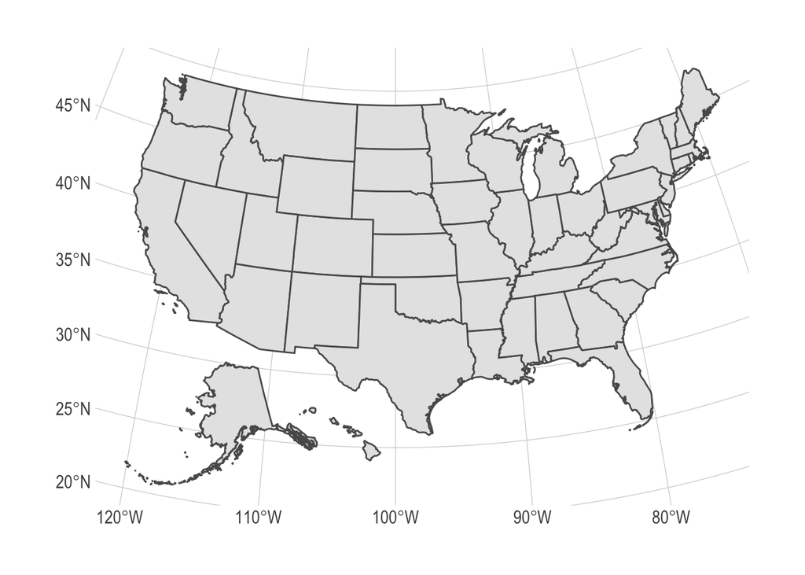

```r
map <- get_acs(geography = "state", variables = "B01003_001", geometry = TRUE, shift_geo = TRUE)

map %>%
  ggplot() +
  geom_sf()
```

This joins the cluster assignments to the map object and summarizes the state polygons by region. This dissolves the state boundaries and creates polygons for each cluster.

```r
map_cluster <- map %>%
  left_join(cluster_assignments %>%
             filter(kclust == best_kclust), by = c("NAME" = "state")) %>%
  add_count(cluster_assignment) %>%
  mutate(cluster_assignment = as.character(cluster_assignment),
         cluster_assignment = fct_reorder(cluster_assignment, desc(n))) %>%
  group_by(cluster_assignment) %>%
  summarize()

state_clustered <- map %>%
  left_join(cluster_assignments %>%
              filter(kclust == best_kclust), by = c("NAME" = "state")) %>%
  add_count(cluster_assignment) %>%
  mutate(cluster_assignment = as.character(cluster_assignment),
         cluster_assignment = fct_reorder(cluster_assignment, desc(n)))
```

This code creates the map, and overlays the state boundaries on the cluster polygons.

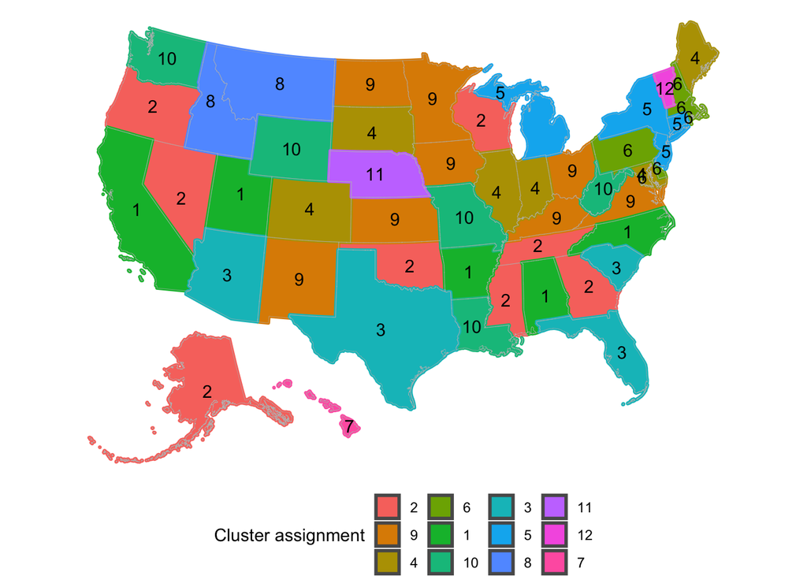

```r
map_cluster %>%
  ggplot() +
  geom_sf(aes(fill = cluster_assignment, color = cluster_assignment),
          size = 1) +
  geom_sf(data = map, color = "grey", size = .1,  alpha = 0) +
  geom_sf_text(data = state_clustered, aes(label = cluster_assignment)) +
  labs(fill = "Cluster assignment",
       color = "Cluster assigmment") +
  guides(color = FALSE) +
  theme_void() +
  theme(legend.position = "bottom",
        legend.direction = "horizontal")
```

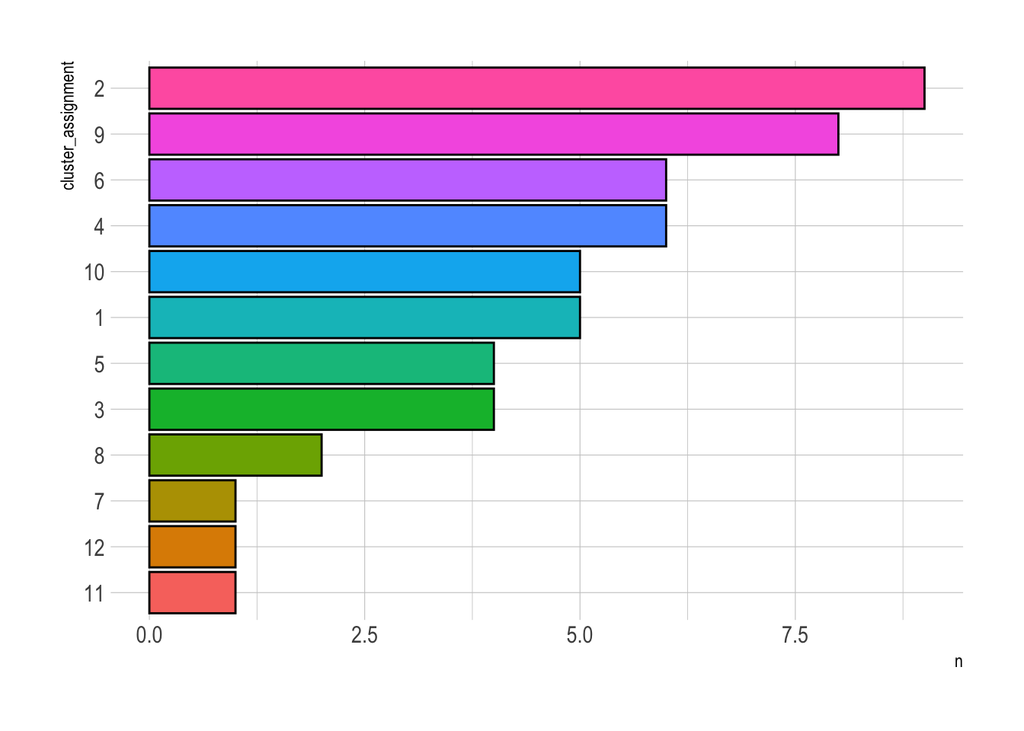

```r
cluster_assignments %>%
  filter(kclust == best_kclust) %>%
  count(cluster_assignment, sort = TRUE) %>%
  mutate(cluster_assignment = as.character(cluster_assignment),
         cluster_assignment = fct_reorder(cluster_assignment, n)) %>%
  ggplot(aes(n, cluster_assignment, fill = cluster_assignment)) +
  geom_col(color = "black", show.legend = FALSE)
```

### Sources

https://rpubs.com/esobolewska/dtw-time-series http://www.rdatamining.com/examples/time-series-clustering-classification http://rstudio-pubs-static.s3.amazonaws.com/398402_abe1a0343a4e4e03977de8f3791e96bb.html